# chapter02_快速探索数据

## 2.2 绘制折线图

- 使用`plot()`函数绘制折线图时需向其传递一个包含x值的向量和一个包含y值的向量，并使用参数type=“l”：

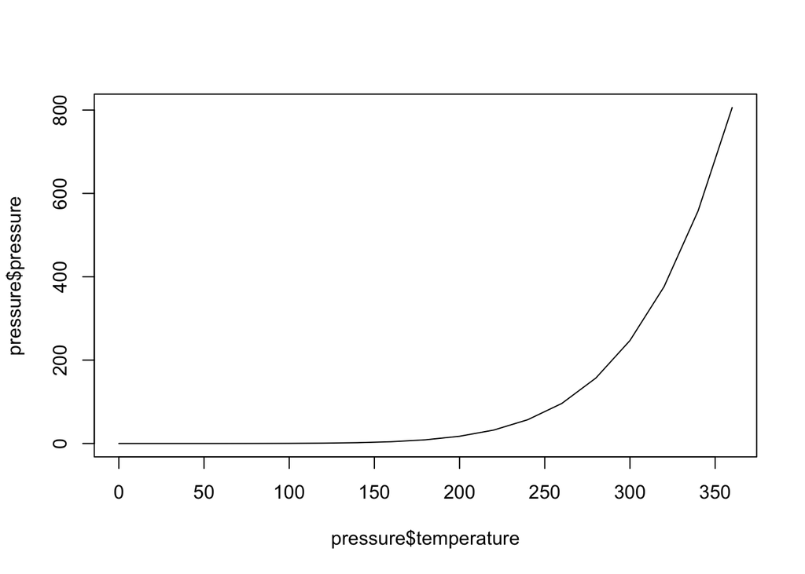

```r
> plot(pressure$temperature,pressure$pressure,type = 'l')
```

- 如果要向图形中添加数据点或者多条折线，则需先用`plot()`函数绘制第一条折线，再通过`points()`函数和`lines()`函数分别添加数据点和更多折线：

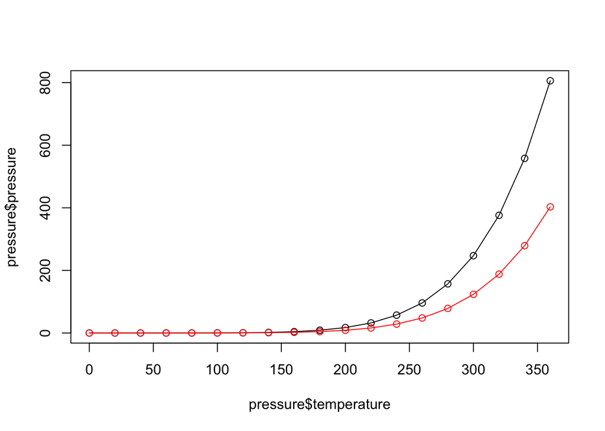

```r
> plot(pressure$temperature,pressure$pressure,type = 'l')
> points(pressure$temperature,pressure$pressure)
> lines(pressure$temperature,pressure$pressure/2,col = 'red')
> points(pressure$temperature,pressure$pressure/2,col = 'red')
```

- 在ggplot2中，可以使用`qplot()`函数并将参数设定为`geom="line"`得到类似的绘图结果：

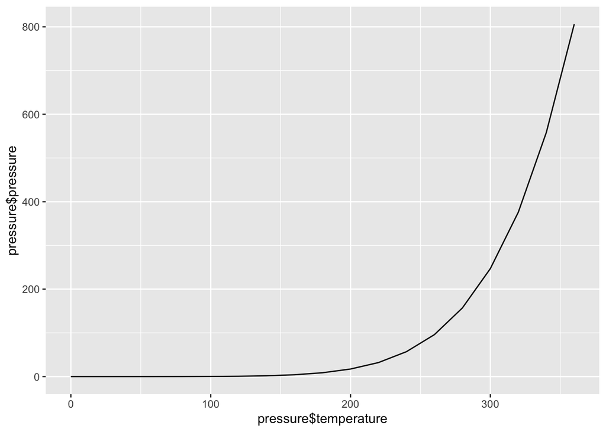

```r
> library(ggplot2)
> qplot(pressure$temperature,pressure$pressure,geom = 'line')
```

- 如果函数的两个参数向量已包含在同一个数据框中，则可以运行下面的语句：

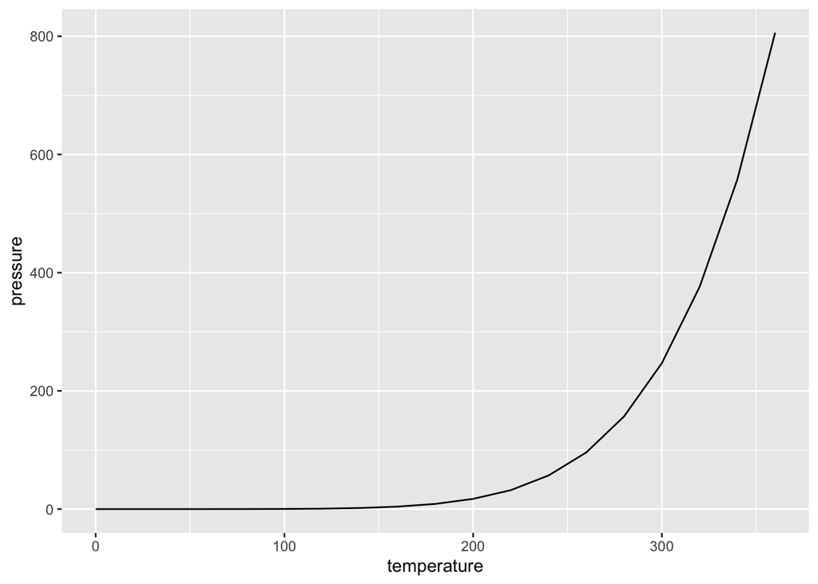

```r
> qplot(temperature,pressure,data = pressure,geom = 'line')
```

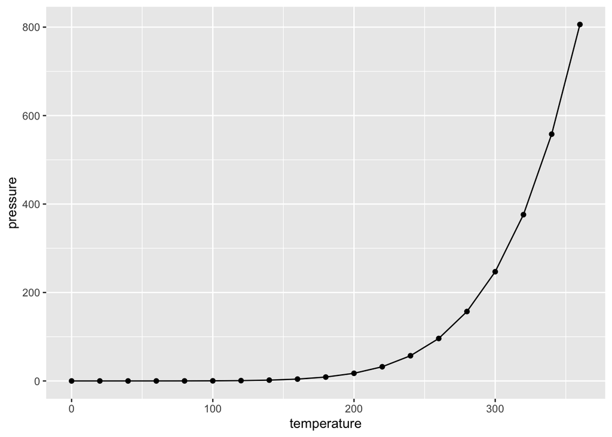

```r
> # 等价于
> # ggplot(pressure,aes(x=temperature,y=pressure)) + geom_line()
>
> # 添加数据点
> qplot(temperature,pressure,data = pressure,geom = c('line','point'))
```

```r
> # 等同于
> # ggplot(pressure,aes(x=temperature,y=pressure)) + geom_line() + geom_point()
```

- 更多关于绘制折线图的详细内容可参见第4章。

## 2.3 绘制条形图

- 对变量的值绘制条形图，可以使用`barplot()`函数，并向其传递两个向量作为参数，第一个向量用来设定条形的高度，第二个向量用来设定每个条形对应的标签（可选）。
- 如果向量中的元素已被命名，则系统会自动使用元素的名字作为条形标签：

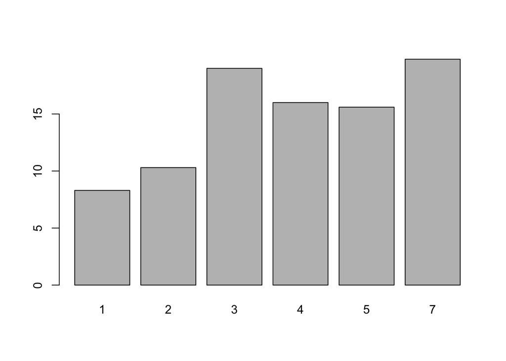

```r
> barplot(BOD$demand,names.arg=BOD$Time)
```

- 有时候，“条形图”表示的是分组数据中各个元素的频数。这种条形图跟直方图有些类似，不过，其用离散取值的x轴替代了直方图中连续取值的x轴。要计算向量中各个类别的频数，可以使用`table()`函数。

```r
> table(mtcars$cyl)

 4  6  8
11  7 14
```

- 值为4的频数为11，6的为7，8的为14。
- 只需将上面的表格结果传递给`barplot()`函数即可绘制频数条形图：

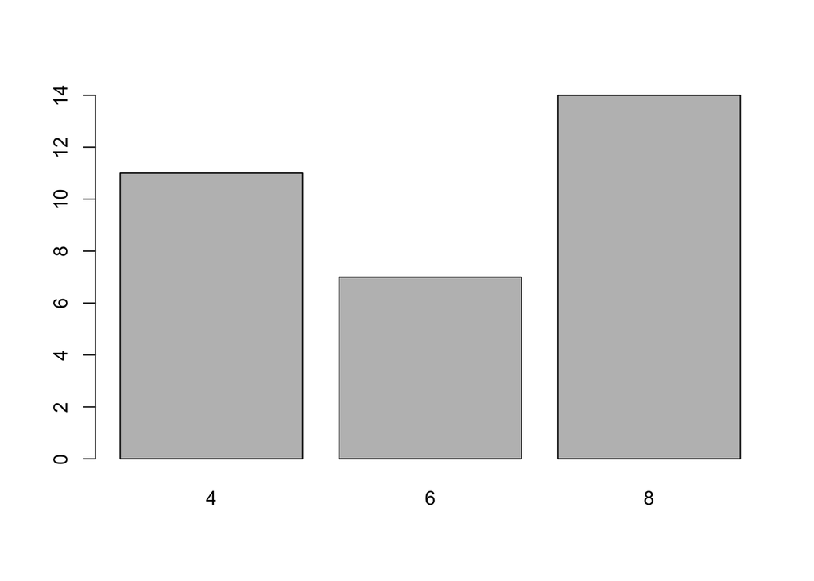

```r
> barplot(table(mtcars$cyl))
```

- 如果参数向量包含在同一个数据框内，则可以运行下面的语句：
- **注意变量x分别为连续取值和离散取值时输出结果的差异**。

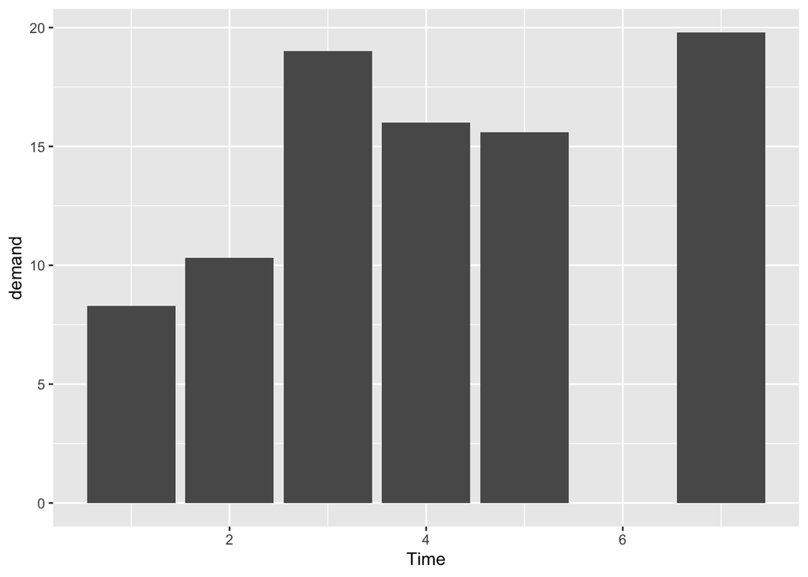

```r
> library(ggplot2)
> # 变量值条形图，这里用BOD数据框中的Time列和demand列分别作为x和y参数
> ggplot(BOD,aes(x=Time,y=demand)) + geom_bar(stat = 'identity')
```

```r
> # 这与下面的语句等价
> # qplot(Time, demand, data=BOD, geom="bar", stat="identity")
```

- 将x转化为因子变量，令系统将其视作离散值:

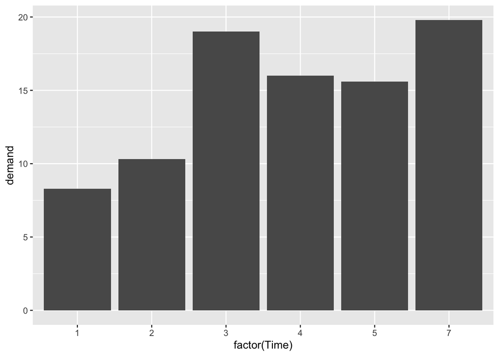

```r
> library(ggplot2)
> ggplot(BOD,aes(x=factor(Time),y=demand)) + geom_bar(stat = 'identity')
```

- **再提醒一次，注意连续x轴和离散x轴的差异。**

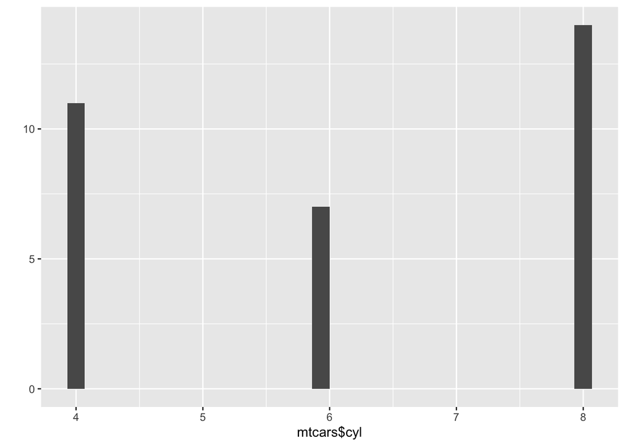

```r
> # cyl是连续变量
> qplot(mtcars$cyl)
```

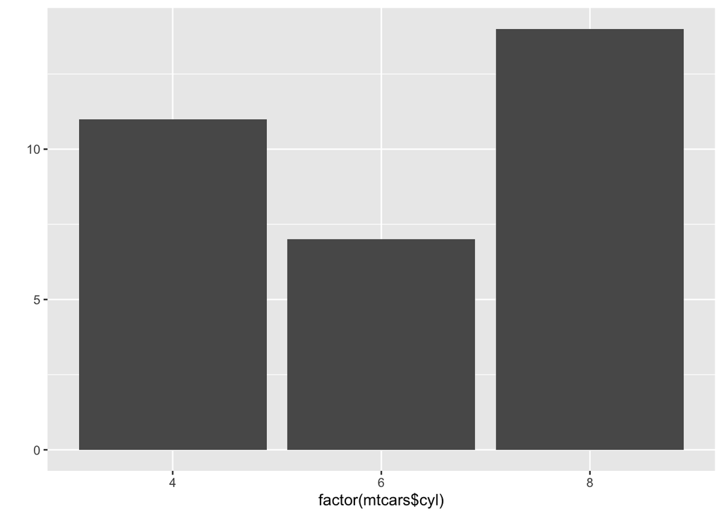

```r
> # 将cyl转化为因子变量
> qplot(factor(mtcars$cyl))
```

```r
> # 这与下面的语句等价
> # qplot (factor(cyl), data=mtcars)
> # ggplot (mtcars, aes(x=factor(cyl))) + geom_bar()
```

- 更多关于绘制条形图的详细内容可参见第3章。